# Reproducible Research: Peer Assessment 1

# Assignment Week 2

First, we need to load and preprocess the data

```r
data <- read.csv("activity.csv")
data$date <- as.Date(data$date,  "%Y-%m-%d")
str(data)
```

```
## 'data.frame':    17568 obs. of  3 variables:
##  $ steps   : int  NA NA NA NA NA NA NA NA NA NA ...
##  $ date    : Date, format: "2012-10-01" "2012-10-01" ...
##  $ interval: int  0 5 10 15 20 25 30 35 40 45 ...
```

## What is mean total number of steps taken per day?

For this part of the assignment, we ignore the missing values in the dataset. First of all, we calculate the total number of steps taken per day and make a histogram of the total number of steps taken each day

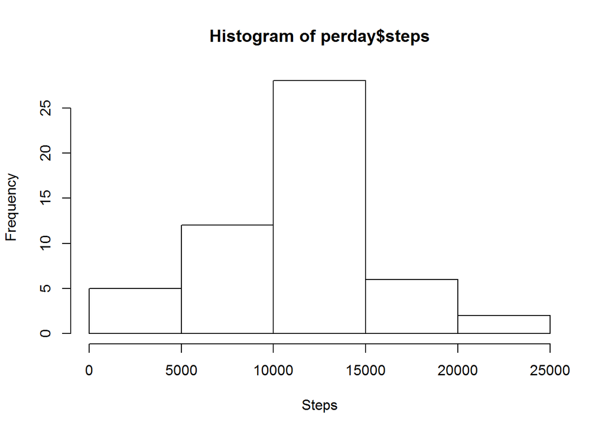

```r
perday <- aggregate(steps~date, data=data, FUN=sum)
hist(perday$steps, xlab="Steps")
```

Now, we calculate and report the mean and median of the total number of steps taken per day.

```r
mean(perday$steps)
```

```
## [1] 10766.19
```

```r
median(perday$steps)
```

```
## [1] 10765
```

## What is the average daily activity pattern?

To answer this question, we make a time series plot of the 5-minute interval and the average number of steps taken, averaged across all days.

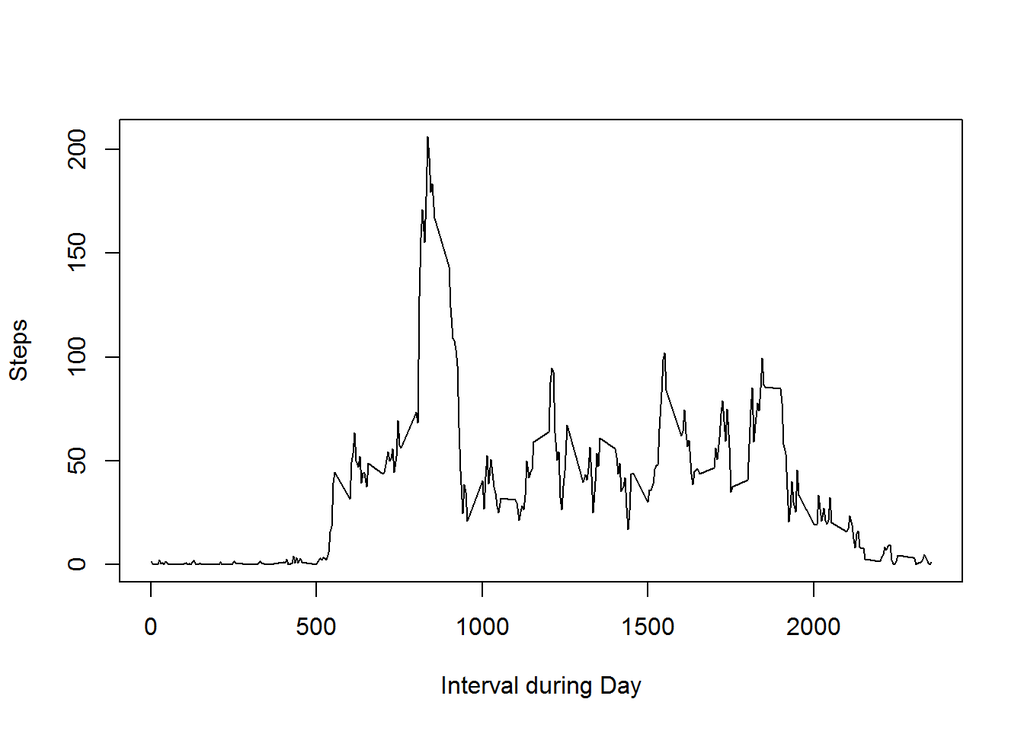

```r
perinterval <- aggregate(steps~interval, data=data, FUN=mean)
plot(perinterval$interval, perinterval$steps, type="l", xlab="Interval during Day", ylab="Steps")
```

To answer the question, which 5-minute interval, on average across all the days in the dataset, contains the maximum number of steps, we nee to look at the maximum.

```r
# find row with max of steps
max_steps_row <- which.max(perinterval$steps)

# find interval with this max
perinterval[max_steps_row, ]
```

```
##     interval    steps
## 104      835 206.1698
```